# Differential Expression of Brain RNA Levels in Lrap Knockout Male Rats and Their Wild Type Controls

Laura Saba

August 18, 2020

## 1. Count raw reads

```
./countRawReads.lrapKO.sh &
```

Number of RNA-Seq samples: 9

Average Number of Read Pairs Per Sample: 54,358,408

**Table 1. Number of raw reads per library.** Each library represents a different biological samples. Libraries were generated from total RNA (>200nt) where ribosomal RNA has been depleted.

| Sample | Number of Read Fragments | Number of Read Pairs | Read Length |
| --- | --- | --- | --- |
| HET-1 | 115,314,008 | 57,657,004 | 101 |
| HET-2 | 120,744,982 | 60,372,491 | 101 |
| HET-3 | 122,391,272 | 61,195,636 | 101 |
| KO-1 | 73,162,260 | 36,581,130 | 101 |
| KO-2 | 119,238,284 | 59,619,142 | 101 |
| KO-3 | 122,736,788 | 61,368,394 | 101 |
| WT-1 | 107,823,136 | 53,911,568 | 101 |
| WT-2 | 105,350,206 | 52,675,103 | 101 |
| WT-3 | 91,690,400 | 45,845,200 | 101 |

## 2. Trim reads

Trim reads for adaptors and poor quality base calls

```
./trimReads.lrapKO.sh &
```

Count number of reads and average read length after trimming

```
./countTrimmedReads.lrapKO.sh &
```

```r
trim_cnts <- read.table(file=paste0(github,"data/trimmedReadCounts.txt"), sep=" ", header=FALSE)
trim_cnts$file_name = unlist(lapply(strsplit(trim_cnts$V1,split="/", fixed=TRUE), function(a) a[length(a)]))
trim_cnts$genotype = unlist(lapply(strsplit(trim_cnts$file_name,split="-", fixed=TRUE), function(a) a[3]))
trim_cnts$bio_rep = unlist(lapply(strsplit(trim_cnts$file_name,split="-", fixed=TRUE), function(a) a[4]))
trim_cnts$sample = paste(trim_cnts$genotype, trim_cnts$bio_rep, sep="-")

trim_cnts$trim_frags = prettyNum(trim_cnts$V3*2, big.mark = ",")
trim_cnts$trim_pairs = prettyNum(trim_cnts$V3, big.mark = ",")
trim_cnts$trim_length = sprintf("%.1f",round(trim_cnts$V2,1))

combo1 = merge(raw_cnts[!duplicated(raw_cnts$sample),],trim_cnts[!duplicated(trim_cnts$sample),], by="sample")
combo1$pct_trimmed = (combo1$V3.x - combo1$V3.y) / combo1$V3.x
combo1$pct_trimmed = paste0(sprintf("%.2f", round(combo1$pct_trimmed*100,2)),"%")

pretty_trimmed = combo1[,c("sample","read_frags","trim_frags","trim_length","pct_trimmed")]
colnames(pretty_trimmed) = c("Sample","Original Number of Read Fragments","Number of Read Fragments After Trimming","Average Trimmed Read Length","Percent of Reads Removed During Trimming")
```

Average number of read pairs per sample after trimming: 54,053,218

Average read fragement length after trimming: 99.3

**Table 2. Results from trimming reads for adaptors and for quality.**

| Sample | Original Number of Read Fragments | Number of Read Fragments After Trimming | Average Trimmed Read Length | Percent of Reads Removed During Trimming |
| --- | --- | --- | --- | --- |
| HET-1 | 115,314,008 | 114,551,602 | 99.4 | 0.66% |
| HET-2 | 120,744,982 | 120,012,876 | 99.2 | 0.61% |
| HET-3 | 122,391,272 | 121,918,608 | 99.0 | 0.39% |
| KO-1 | 73,162,260 | 72,595,822 | 99.5 | 0.77% |
| KO-2 | 119,238,284 | 118,596,234 | 99.7 | 0.54% |
| KO-3 | 122,736,788 | 121,871,622 | 99.5 | 0.70% |
| WT-1 | 107,823,136 | 107,346,862 | 99.9 | 0.44% |
| WT-2 | 105,350,206 | 104,789,224 | 98.7 | 0.53% |
| WT-3 | 91,690,400 | 91,275,080 | 99.7 | 0.45% |

## 3. Align to genome

Align to rat rn6 genome using HISAT2

```
./alignToGenome.KO.sh &
./alignToGenome.Het.sh &
./alignToGenome.WT.sh &
```

Sort and merge aligned reads in preparation for transcriptome reconstruction

```
./sortAlignedReads.KO.sh
./sortAlignedReads.Het.sh
./sortAlignedReads.WT.sh
```

Summary of percent of reads aligned to the genome

```r
samples = c("WT1","WT2","WT3","HET1","HET2","HET3","KO1","KO2","KO3")
for (i in samples){
  x <- read.table(file=paste0(bf,"data/alignNotes_",i,".txt"),sep="\t")
  y <- x[grep(") aligned 0 times",x$V1),]
  y2 <- x$V1[1]
  z <- data.frame(sample = i,
                trimmed = 2*as.numeric(strsplit(trim(y2),split=" ",fixed=TRUE)[[1]][1]),
                unmapped = as.numeric(strsplit(trim(y),split=" ",fixed=TRUE)[[1]][1]))
  if(i==samples[1]) genome_align = z
  if(i!=samples[1]) genome_align = rbind(genome_align,z)
}

genome_align$pct_aligned = (genome_align$trimmed - genome_align$unmapped) / genome_align$trimmed
genome_align$pct_aligned = paste0(sprintf("%.1f", round(genome_align$pct_aligned*100,1)),"%")

pretty_gAlign = genome_align[,c("sample","trimmed","unmapped","pct_aligned")]
pretty_gAlign$trimmed = prettyNum(pretty_gAlign$trimmed,big.mark=",")
pretty_gAlign$unmapped = prettyNum(pretty_gAlign$unmapped,big.mark=",")

colnames(pretty_gAlign) = c("Sample","Number of Read Fragments After Trimming","Number of Reads That Did Not Align to the Genome","Percent of Reads Aligned to Genome")
```

Average rate of alignment: 89.7%

**Table 3. Results from alignment to the genome.**

| Sample | Number of Read Fragments After Trimming | Number of Reads That Did Not Align to the Genome | Percent of Reads Aligned to Genome |
| --- | --- | --- | --- |
| WT1 | 107,346,862 | 11,655,151 | 89.1% |
| WT2 | 104,789,224 | 7,823,490 | 92.5% |
| WT3 | 91,275,080 | 6,337,135 | 93.1% |
| HET1 | 114,551,602 | 9,695,759 | 91.5% |
| HET2 | 120,012,876 | 7,896,458 | 93.4% |
| HET3 | 121,918,608 | 17,750,485 | 85.4% |
| KO1 | 72,595,822 | 9,950,996 | 86.3% |
| KO2 | 118,596,234 | 12,925,826 | 89.1% |
| KO3 | 121,871,622 | 15,727,497 | 87.1% |

## 4. Transcriptome reconstruction

Transcriptome reconstruction by genotype using StringTie

```
stringtie /data/hi-seq/LRAP.KO/alignedReads/HISAT2/HET.naive.bam -p 8 -o /data/home/sabal/lncRNA.KO/RNA-Seq/reconstruction_v2/lncKO_Het_Recon.gtf -G /data/home/sabal/gtfFiles/ensembl.Rnor_6.0.85.wLRAP.gtf &
stringtie /data/hi-seq/LRAP.KO/alignedReads/HISAT2/WT.naive.bam -p  8 -o /data/home/sabal/lncRNA.KO/RNA-Seq/reconstruction_v2/lncKO_WT_Recon.gtf -G /data/home/sabal/gtfFiles/ensembl.Rnor_6.0.85.wLRAP.gtf &
stringtie /data/hi-seq/LRAP.KO/alignedReads/HISAT2/KO.naive.bam -p  8 -o /data/home/sabal/lncRNA.KO/RNA-Seq/reconstruction_v2/lncKO_KO_Recon.gtf -G /data/home/sabal/gtfFiles/ensembl.Rnor_6.0.85.wLRAP.gtf &
```

Merge genotype transcriptomes

```
stringtie --merge -m 50 -f 0.001 -c 0 -F 0 -T 0 -p 8 -o lncKO_merged_Recon_v2.gtf lncKO_WT_Recon.gtf lncKO_Het_Recon.gtf  lncKO_KO_Recon.gtf
```

Compare reconstructed transcriptome with Ensembl transcriptome

```
gffcompare -r ensembl.Rnor_6.0.85.wLRAP.gtf -G -o lncKO_merged_wEnsembl lncKO_merged_Recon_v2.gtf
```

## 5. Quantitate the reconstructed transcriptome

Prepare RSEM reference transcriptome from StringTie GTF

```
rsem-prepare-reference --gtf /data/home/sabal/lncRNA.KO/RNA-Seq/reconstruction_v2/lncKO_merged_Recon_v2.gtf --bowtie2 /data/rn6/index/BNLx.rn6.spikes.fa /data/home/sabal/lncRNA.KO/RNA-Seq/reconstruction_v2/lncKO_merged_Recon.hisat &
```

Estimate read counts of individual biological replicates using RSEM (i.e., alignment directly to the transcriptome)

```
./RSEMquant.koRecon_v2.sh
```

Summarize transcriptome alignment rates

```r
samples = c("WT1","WT2","WT3","Het1","Het2","Het3","KO1","KO2","KO3")

for(i in samples){
  x <- read.table(file=paste0(bf,"quantitation/RSEM.koRecon_v2/",i,".naive.stat/",i,".naive.cnt"),sep=" ",nrows=1)
  y <- data.frame(sample=i,num_trimmed = x$V4, num_aligned = x$V2)
  if(i==samples[1]) aligned = y
  if(i!=samples[1]) aligned = rbind(aligned,y)
}

aligned$pct_aligned = aligned$num_aligned/aligned$num_trimmed

pretty_aligned = aligned
pretty_aligned$pct_aligned = paste0(sprintf("%.1f",round(pretty_aligned$pct_aligned*100,1)),"%")
pretty_aligned$num_trimmed = prettyNum(pretty_aligned$num_trimmed, big.mark=",")
pretty_aligned$num_aligned = prettyNum(pretty_aligned$num_aligned, big.mark=",")

colnames(pretty_aligned) <- c("Sample","Number of Read Fragments After Trimming","Number of Read Fragments Aligned to the Reconstructed Transcriptome","Percent of Read Fragments Aligned to Transcriptome")
```

**Table 4. Results from alignment to the reconstructed transcriptome.**

| Sample | Number of Read Fragments After Trimming | Number of Read Fragments Aligned to the Reconstructed Transcriptome | Percent of Read Fragments Aligned to Transcriptome |
| --- | --- | --- | --- |
| WT1 | 53,673,431 | 38,705,205 | 72.1% |
| WT2 | 52,394,612 | 36,936,415 | 70.5% |
| WT3 | 45,637,540 | 35,511,296 | 77.8% |
| Het1 | 57,275,801 | 41,165,555 | 71.9% |
| Het2 | 60,006,438 | 44,779,779 | 74.6% |
| Het3 | 60,959,304 | 48,401,535 | 79.4% |
| KO1 | 36,297,911 | 28,250,487 | 77.8% |
| KO2 | 59,298,117 | 44,794,649 | 75.5% |
| KO3 | 60,935,811 | 48,339,052 | 79.3% |

## 6. Differential Expression

### Identify sums of isoforms (SOI) and isoforms that are linked to Ensembl protein coding genes

```r
gtf = read.table(file=paste(bf,"reconstruction_v2/lncKO_merged_wEnsembl.annotated.gtf",sep=""),sep="\t",header=FALSE)

transcripts = gtf %>% filter(V3=="transcript")

extractVars = function(data,column,var) unlist(lapply(strsplit(data[,column],split=";",fixed=TRUE), function(a) gsub(paste(var," ",sep=""),"",a[grep(var,a)])))

transcripts$transcript_id = extractVars(transcripts,"V9","transcript_id")
transcripts$gene_id = extractVars(transcripts,"V9","gene_id")
transcripts$class_code = extractVars(transcripts,"V9","class_code")
transcripts$gene_name = NA
transcripts$gene_name[grep("gene_name",transcripts$V9)] = extractVars(transcripts,"V9","gene_name")
transcripts$ensembl = NA
transcripts$ensembl[grep("cmp_ref",transcripts$V9)] = extractVars(transcripts,"V9","cmp_ref")

anno = transcripts[,c("V1","V4","V5","V7","transcript_id","gene_id","class_code","gene_name","ensembl")]
colnames(anno)[1:4] = c("chr","start","end","strand")

ensembl_genes <- read.table(file=paste(bf,"data/ensembl_to_ncbi.2018-11-08.rno.ensembl94.txt",sep=""),sep="\t",header=FALSE)

protein_coding <- anno[anno$class_code %in% c(" ="," j"),]
protein_coding <- protein_coding[trim(protein_coding$ensembl) %in% ensembl_genes$V1[ensembl_genes$V3=="protein_coding"] | (!is.na(protein_coding$gene_name) & grepl("LRAP",protein_coding$gene_name)),]
```

### Differential expression - Isoform Level

Generate count matrix and limit to isoforms that: 1) are associated with a protein-coding Ensembl gene and 2) have more than 50 summed across wildtype and knockout rats

Number of isoforms from protein-coding genes are that are expressed above background: 33,063

**Figure 1. Relationships among samples using isoform read counts for isoforms from protein coding genes that are expressed above background.** Dendrogram was calculated using one minus the Spearman correlation coefficient as a measure of distance. Counts were adjusted for library size.

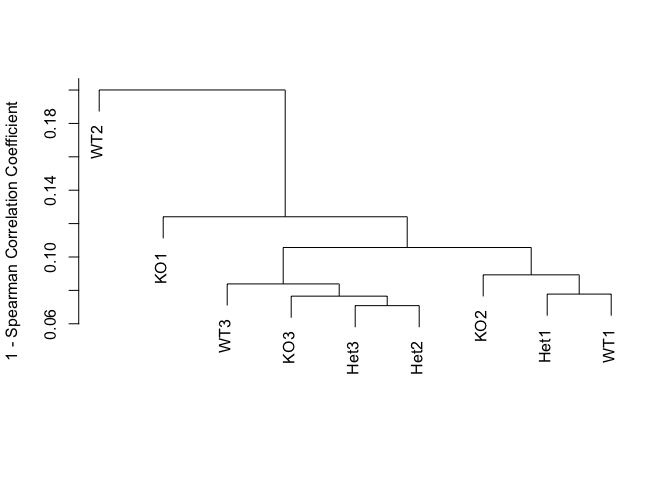

```r
plot(hclust(as.dist(1-cor(norm_cnts_isoform,method="spearman"))),ylab="1 - Spearman Correlation Coefficient", main="", xlab="", sub="")
```

Number of isoforms that were analyzed by DESeq2: 32,649

### Differential expression - Gene Level

Generate count matrix and limit to genes that: 1) are associated with a protein-coding Ensembl gene and 2) have more than 50 summed across wildtype and knockout rats

Number of protein-coding genes are that are expressed above background: 14,114

**Figure 2. Relationships among samples using gene read counts for protein coding genes that are expressed above background.** Dendrogram was calculated using one minus the Spearman correlation coefficient as a measure of distance. Counts were adjusted for library size.

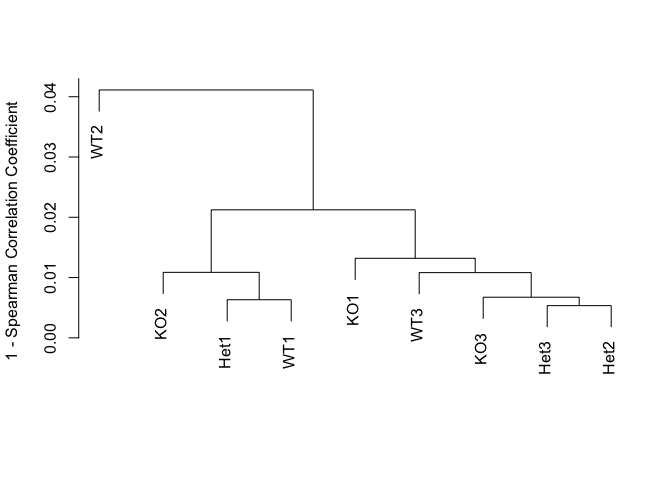

```r
plot(hclust(as.dist(1-cor(norm_cnts_gene,method="spearman"))),ylab="1 - Spearman Correlation Coefficient", main="", xlab="", sub="")
```

Number of genes that were analyzed by DESeq2: 14,104

### Combine DE results with annotation

```r
## Sig Isoforms/Sig Genes

sig_isoforms <- combined_results %>%
  filter((!is.na(padj) & padj<0.10) | (!is.na(padj_gene) & padj_gene<0.10))

## Numbers of Sig Isoforms/Genes

#length(unique(sig_isoforms$gene_id))                         # number of sig genes - 751 (either gene or at least one isoform of the gene)
#sum(!is.na(sig_isoforms$padj) & sig_isoforms$padj<0.10)      # number of sig isoforms - 782

#save(combined_results, sig_isoforms, file=paste(bf,"Rdata/rnaSeqResults.",Sys.Date(),".Rdata",sep=""))
```

Number of significant genes (FDR<0.10 for either the gene or at least one isoform of the gene): 750

Number of significant isoforms (FDR<0.10): 781

```r
#load(file=paste(bf,"Rdata/rnaSeqResults.","2019-01-23",".Rdata",sep=""))


#Summary Table for Number of Significant Genes/Transcripts
gene_results <- combined_results[!duplicated(combined_results$gene_id),]

num_transcripts = sum(!is.na(combined_results$padj))

combined_v2 = combined_results
combined_v2$KO_pctWT[combined_v2$KO_median==0 & combined_v2$WT_median==0] = 1
combined_v2$KO_pctWT[combined_v2$KO_median==0 | combined_v2$WT_median==0] = 99


summary_results <- combined_v2 %>%
  filter(!is.na(padj)) %>%
  mutate(FDR0001 = as.numeric(padj<0.0001),
         FDR001 = as.numeric(padj<0.001),
         FDR01 = as.numeric(padj<0.01),
         FDR05 = as.numeric(padj<0.05),
         FDR10 = as.numeric(padj<0.10),
         pct50 = as.numeric(KO_pctWT>1.5 | (1/KO_pctWT)>1.5),
         pct100 = as.numeric(KO_pctWT>2 | (1/KO_pctWT)>2))

table_results <- data.frame(threshold = c(0.10, 0.05, 0.01, 0.001, 0.0001),
                            num_sig = colSums(summary_results[,c("FDR10","FDR05","FDR01","FDR001","FDR0001")]),
                            num_sig_100 = colSums(summary_results[summary_results$pct100==1,c("FDR10","FDR05","FDR01","FDR001","FDR0001")]),
                            num_sig_50 = colSums(summary_results[summary_results$pct50==1,c("FDR10","FDR05","FDR01","FDR001","FDR0001")]))

colnames(table_results) = c("FDR Threshold","Number of Significant Isoforms","Number of Significant Isoforms with at least a 1-fold difference in expression","Number of Significant Isoforms with at least a 0.5-fold difference in expression")
```

**Table 5. Summary of number of significantly differentially expressed isoforms at various FDR thresholds.**

| FDR Threshold | Number of Significant Isoforms | Number of Significant Isoforms with at least a 1-fold difference in expression | Number of Significant Isoforms with at least a 0.5-fold difference in expression |
| --- | --- | --- | --- |
| 1e-01 | 781 | 347 | 524 |
| 5e-02 | 540 | 277 | 386 |
| 1e-02 | 292 | 191 | 234 |
| 1e-03 | 161 | 132 | 145 |
| 1e-04 | 117 | 102 | 108 |

```r
combined_v3 = combined_results[!duplicated(combined_results$gene_id),]
combined_v3$KO_pctWT_gene[combined_v3$KO_median_gene==0 & combined_v3$WT_median_gene==0] = 1
combined_v3$KO_pctWT_gene[combined_v3$KO_median_gene==0 | combined_v3$WT_median_gene==0] = 99


summary_results_gene <- combined_v3 %>%
  filter(!is.na(padj_gene)) %>%
  mutate(FDR0001 = as.numeric(padj_gene<0.0001),
         FDR001 = as.numeric(padj_gene<0.001),
         FDR01 = as.numeric(padj_gene<0.01),
         FDR05 = as.numeric(padj_gene<0.05),
         FDR10 = as.numeric(padj_gene<0.10),
         pct50 = as.numeric(KO_pctWT_gene>1.5 | (1/KO_pctWT_gene)>1.5),
         pct100 = as.numeric(KO_pctWT_gene>2 | (1/KO_pctWT_gene)>2))

table_results_gene <- data.frame(threshold = c(0.10, 0.05, 0.01, 0.001, 0.0001),
                            num_sig = colSums(summary_results_gene[,c("FDR10","FDR05","FDR01","FDR001","FDR0001")]),
                            num_sig_100 = colSums(summary_results_gene[summary_results_gene$pct100==1,c("FDR10","FDR05","FDR01","FDR001","FDR0001")]),
                            num_sig_50 = colSums(summary_results_gene[summary_results_gene$pct50==1,c("FDR10","FDR05","FDR01","FDR001","FDR0001")]))
colnames(table_results_gene) = c("FDR Threshold","Number of Significant Genes","Number of Significant Genes with at least a 1-fold difference in expression","Number of Significant Genes with at least a 0.5-fold difference in expression")
```

**Table 6. Summary of number of significantly differentially expressed genes at various FDR thresholds.**

| FDR Threshold | Number of Significant Genes | Number of Significant Genes with at least a 1-fold difference in expression | Number of Significant Genes with at least a 0.5-fold difference in expression |
| --- | --- | --- | --- |
| 1e-01 | 72 | 19 | 49 |
| 5e-02 | 49 | 17 | 36 |
| 1e-02 | 4 | 4 | 4 |
| 1e-03 | 1 | 1 | 1 |
| 1e-04 | 1 | 1 | 1 |